# Practical Machine Learning - Course Project

Sangwon Han

4 Jan 2019

# Overview

The training data for this project are available here: https://d396qusza40orc.cloudfront.net/predmachlearn/pml-training.csv

The test data are available here: https://d396qusza40orc.cloudfront.net/predmachlearn/pml-testing.csv

# Data loading

Download and explore the data.

```r
setwd("/Users/Han S/Documents/Course8")
download.file("https://d396qusza40orc.cloudfront.net/predmachlearn/pml-training.csv", destfile = "training.csv")
download.file("https://d396qusza40orc.cloudfront.net/predmachlearn/pml-testing.csv", destfile = "testing.csv")
train <- read.csv("training.csv", na.strings=c("", "NA", "NULL", "#DIV/0!"))
test <- read.csv("testing.csv", na.strings=c("", "NA", "NULL", "#DIV/0!"))
```

```r
dim(train)
```

```
## [1] 19622   160
```

```r
str(test)
```

```
## 'data.frame':    20 obs. of  160 variables:
##  $ X                       : int  1 2 3 4 5 6 7 8 9 10 ...
##  $ user_name               : Factor w/ 6 levels "adelmo","carlitos",..: 6 5 5 1 4 5 5 5 2 3 ...
##  $ raw_timestamp_part_1    : int  1323095002 1322673067 1322673075 1322832789 1322489635 1322673149 1322673128 1322673076 1323084240 1322837822 ...
##  $ raw_timestamp_part_2    : int  868349 778725 342967 560311 814776 510661 766645 54671 916313 384285 ...
##  $ cvtd_timestamp          : Factor w/ 11 levels "02/12/2011 13:33",..: 5 10 10 1 6 11 11 10 3 2 ...
##  $ new_window              : Factor w/ 1 level "no": 1 1 1 1 1 1 1 1 1 1 ...
##  $ num_window              : int  74 431 439 194 235 504 485 440 323 664 ...
##  $ roll_belt               : num  123 1.02 0.87 125 1.35 -5.92 1.2 0.43 0.93 114 ...
##  $ pitch_belt              : num  27 4.87 1.82 -41.6 3.33 1.59 4.44 4.15 6.72 22.4 ...
##  $ yaw_belt                : num  -4.75 -88.9 -88.5 162 -88.6 -87.7 -87.3 -88.5 -93.7 -13.1 ...
##  $ total_accel_belt        : int  20 4 5 17 3 4 4 4 4 18 ...
##  $ kurtosis_roll_belt      : logi  NA NA NA NA NA NA ...
##  $ kurtosis_picth_belt     : logi  NA NA NA NA NA NA ...
##  $ kurtosis_yaw_belt       : logi  NA NA NA NA NA NA ...
```

[output cut: 86 more lines]

```r
dim(test)
```

```
## [1]  20 160
```

# Pre-processing data

1. Cleansing data

Remove NA values

```r
train_dena <- train[, colSums(is.na(train)) == 0]
dim(train_dena)
```

```
## [1] 19622    60
```

Then, remove 1st to 7th colums since they are unlikely to be related to dependent variable

```r
train_clean <- train_dena[, 8:60]
dim(train_clean)
```

```
## [1] 19622    53
```

Remove the variables that have near zero variance (only numeric variables were evaluated)

```r
suppressMessages(library(caret))
zeroVar = nearZeroVar(train_clean[sapply(train_clean, is.numeric)], saveMetrics = TRUE)
train_nzv = train_clean[, zeroVar[, "nzv"] == FALSE]
```

Remove highly correlated variables with a cut-off value of 90% (only numeric variables were evaluated).

```r
suppressMessages(library(caret))
corrMatrix <- cor(na.omit(train_nzv[sapply(train_nzv, is.numeric)]))
removecor <- findCorrelation(corrMatrix, cutoff = 0.90, verbose = FALSE)
train_decor <- train_nzv[, -removecor]
dim(train_decor)
```

```
## [1] 19622    46
```

2. Split data for cross validation

```r
set.seed(12345)
inTrain <- createDataPartition(y = train_decor$classe, p = 0.7, list = FALSE)
training <- train_decor[inTrain, ]; testing <- train_decor[-inTrain, ]
dim(training); dim(testing)
```

```
## [1] 13737    46
```

```
## [1] 5885   46
```

# Decision tree model

1-1. Building the decision tree model with caret package

```r
set.seed(12345)
modFit <- train(classe ~ ., method = "rpart", data = training)
```

1-2. Building the decision tree model with tree package

```r
suppressMessages(library(tree))
set.seed(12345)
modFit_tree <- tree(classe ~ ., data = training)
```

## Fig1. Tree plot - caret

```r
suppressMessages(library(rattle))
```

[figure not shown]

```r
fancyRpartPlot(modFit$finalModel)
```

## Fig2. Tree plot - tree

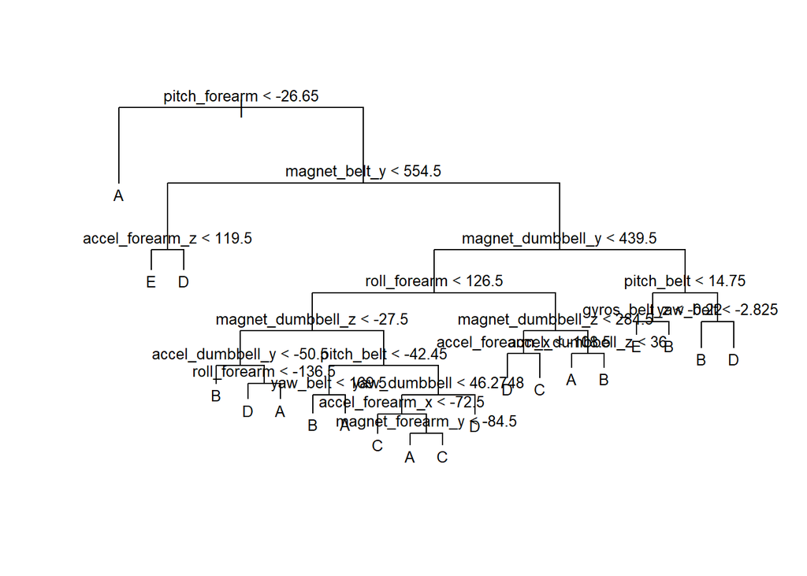

```r
plot(modFit_tree)
text(modFit_tree, cex = 0.8, pretty = 0)
```

2-1. Predicting with the decision tree model (caret)

```r
prediction <- predict(modFit, newdata = testing)
confusionMatrix(prediction, testing$classe)
```

```
## Confusion Matrix and Statistics
##
##           Reference
## Prediction    A    B    C    D    E
##          A 1078  211   35   53   21
##          B  286  671  163  359  258
##          C  310  254  816  467  288
##          D    0    0    0    0    0
##          E    0    3   12   85  515
##
## Overall Statistics
##
##                Accuracy : 0.5234
##                  95% CI : (0.5105, 0.5362)
##     No Information Rate : 0.2845
##     P-Value [Acc > NIR] : < 2.2e-16
##
##                   Kappa : 0.3988
##  Mcnemar's Test P-Value : < 2.2e-16
##
## Statistics by Class:
##
##                      Class: A Class: B Class: C Class: D Class: E
## Sensitivity            0.6440   0.5891   0.7953   0.0000  0.47597
## Specificity            0.9240   0.7754   0.7285   1.0000  0.97918
## Pos Pred Value         0.7711   0.3863   0.3822      NaN  0.83740
## Neg Pred Value         0.8672   0.8872   0.9440   0.8362  0.89241
## Prevalence             0.2845   0.1935   0.1743   0.1638  0.18386
## Detection Rate         0.1832   0.1140   0.1387   0.0000  0.08751
## Detection Prevalence   0.2376   0.2952   0.3628   0.0000  0.10450
## Balanced Accuracy      0.7840   0.6823   0.7619   0.5000  0.72758
```

2-2. Predicting with the decision tree model (tree)

```r
prediction_tree <- predict(modFit_tree, testing, type = "class")
confusionMatrix(prediction_tree, testing$classe)
```

```
## Confusion Matrix and Statistics
##
##           Reference
## Prediction    A    B    C    D    E
##          A 1438  159   10   47   11
##          B   60  647   78   35  244
##          C   77  197  814  264  263
##          D   99  135  124  618  156
##          E    0    1    0    0  408
##
## Overall Statistics
##
##                Accuracy : 0.6669
##                  95% CI : (0.6547, 0.679)
##     No Information Rate : 0.2845
##     P-Value [Acc > NIR] : < 2.2e-16
##
##                   Kappa : 0.5797
##  Mcnemar's Test P-Value : < 2.2e-16
##
## Statistics by Class:
##
##                      Class: A Class: B Class: C Class: D Class: E
## Sensitivity            0.8590   0.5680   0.7934   0.6411  0.37708
## Specificity            0.9461   0.9121   0.8352   0.8955  0.99979
## Pos Pred Value         0.8637   0.6081   0.5040   0.5459  0.99756
## Neg Pred Value         0.9441   0.8979   0.9504   0.9272  0.87692
## Prevalence             0.2845   0.1935   0.1743   0.1638  0.18386
## Detection Rate         0.2444   0.1099   0.1383   0.1050  0.06933
## Detection Prevalence   0.2829   0.1808   0.2744   0.1924  0.06950
## Balanced Accuracy      0.9026   0.7401   0.8143   0.7683  0.68844
```

The model using “tree” package showed a higher accuracy

3. Pruning trees by cross validation

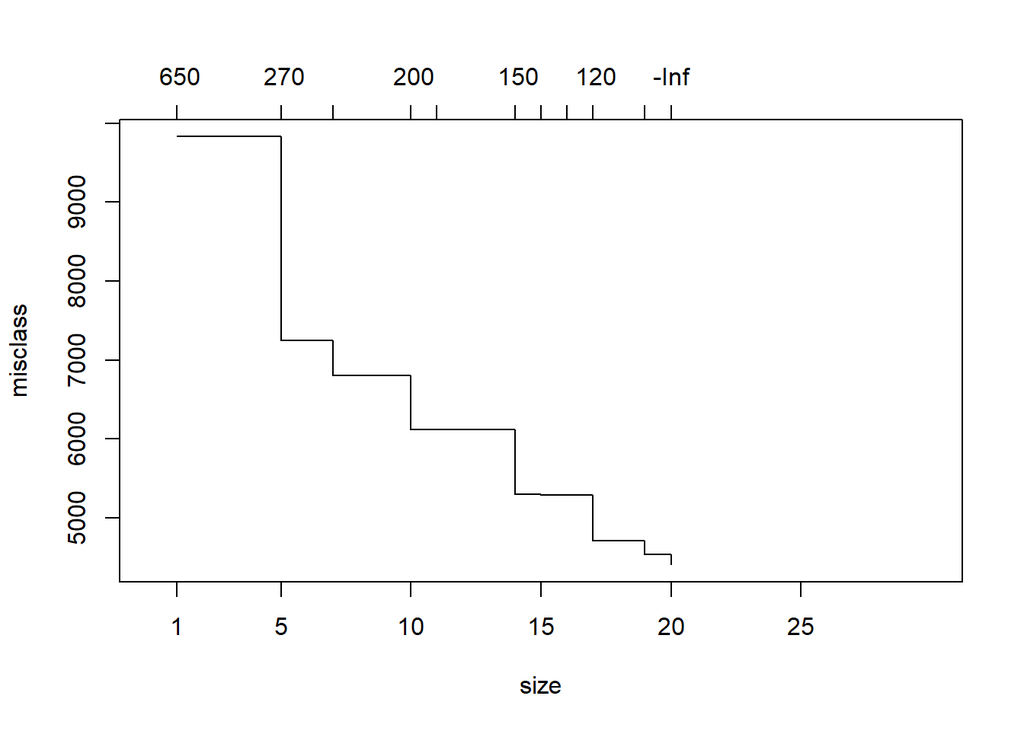

```r
cv.trees <- cv.tree(modFit_tree, FUN = prune.misclass)
plot(cv.trees, xlim = c(0, 30))
```

Therefore, pruning is not necessary. However, for the practical purpose, prune at the size of nodes of 10

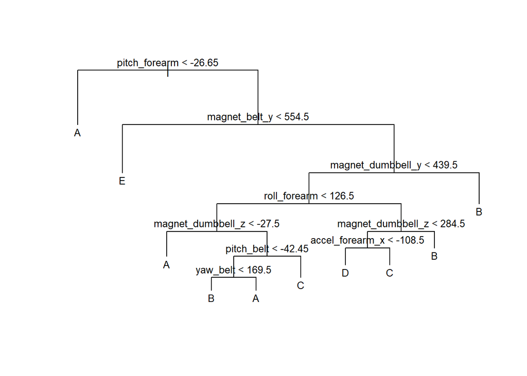

```r
modFit_tree_prune = prune.misclass(modFit_tree, best = 10)
plot(modFit_tree_prune)
text(modFit_tree_prune, cex = 0.8, pretty = 0)
```

# Random Forest Model

```r
suppressMessages(library(randomForest))
set.seed(12345)
modFit_rf <- randomForest(classe ~ ., data = training, method = "rf")
prediction_rf <- predict(modFit_rf, newdata = testing, type = "class")
confusionMatrix(prediction_rf, testing$classe)
```

```
## Confusion Matrix and Statistics
##
##           Reference
## Prediction    A    B    C    D    E
##          A 1672    9    0    0    0
##          B    2 1126   14    0    0
##          C    0    4 1012   13    0
##          D    0    0    0  951    4
##          E    0    0    0    0 1078
##
## Overall Statistics
##
##                Accuracy : 0.9922
##                  95% CI : (0.9896, 0.9943)
##     No Information Rate : 0.2845
##     P-Value [Acc > NIR] : < 2.2e-16
##
##                   Kappa : 0.9901
##  Mcnemar's Test P-Value : NA
##
## Statistics by Class:
##
##                      Class: A Class: B Class: C Class: D Class: E
## Sensitivity            0.9988   0.9886   0.9864   0.9865   0.9963
## Specificity            0.9979   0.9966   0.9965   0.9992   1.0000
## Pos Pred Value         0.9946   0.9860   0.9835   0.9958   1.0000
## Neg Pred Value         0.9995   0.9973   0.9971   0.9974   0.9992
## Prevalence             0.2845   0.1935   0.1743   0.1638   0.1839
## Detection Rate         0.2841   0.1913   0.1720   0.1616   0.1832
## Detection Prevalence   0.2856   0.1941   0.1749   0.1623   0.1832
## Balanced Accuracy      0.9983   0.9926   0.9914   0.9929   0.9982
```

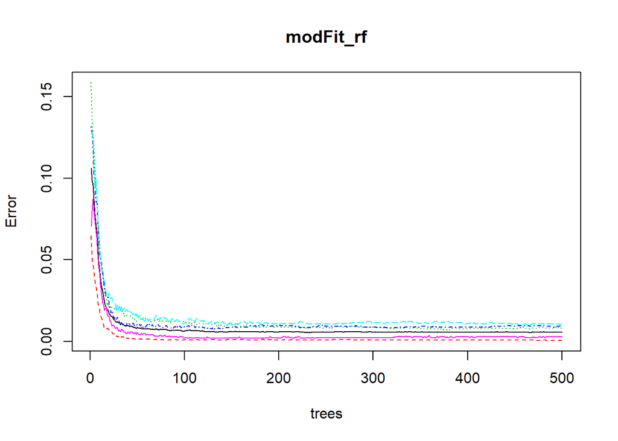

```r
plot(modFit_rf)
```

See which variables are important.

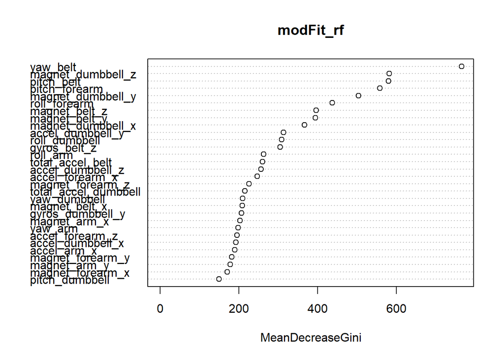

```r
varImpPlot(modFit_rf)
```

# Boosting Model

```r
set.seed(12345)
modFit_boost <- train(classe ~ ., data = training, method = "gbm", verbose = FALSE)
```

See relative influence of each predictor

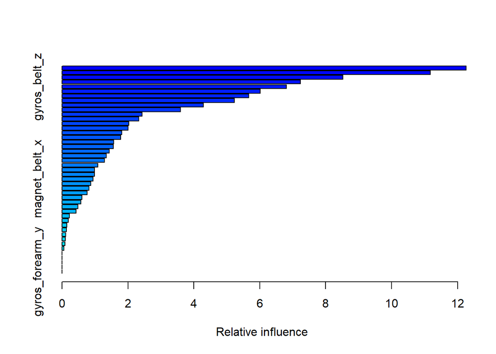

```
##                                       var     rel.inf
## yaw_belt                         yaw_belt 12.26031158
## pitch_forearm               pitch_forearm 11.17427415
## magnet_belt_y               magnet_belt_y  8.52502203
## magnet_dumbbell_z       magnet_dumbbell_z  7.23704630
## gyros_belt_z                 gyros_belt_z  6.80441392
## magnet_dumbbell_y       magnet_dumbbell_y  6.01160918
## magnet_belt_z               magnet_belt_z  5.67161652
## roll_forearm                 roll_forearm  5.23198160
## roll_dumbbell               roll_dumbbell  4.28965053
## pitch_belt                     pitch_belt  3.59976507
## total_accel_belt         total_accel_belt  2.42730245
## accel_forearm_x           accel_forearm_x  2.32835038
## magnet_forearm_z         magnet_forearm_z  2.02788397
## gyros_dumbbell_y         gyros_dumbbell_y  2.00439180
## accel_dumbbell_x         accel_dumbbell_x  1.81236950
## accel_forearm_z           accel_forearm_z  1.78677027
## magnet_dumbbell_x       magnet_dumbbell_x  1.56486412
## yaw_arm                           yaw_arm  1.56168493
## accel_dumbbell_y         accel_dumbbell_y  1.43278533
## magnet_arm_z                 magnet_arm_z  1.34863412
## accel_dumbbell_z         accel_dumbbell_z  1.28497328
## roll_arm                         roll_arm  1.08638694
## gyros_belt_y                 gyros_belt_y  0.99145539
## gyros_belt_x                 gyros_belt_x  0.98403594
## magnet_belt_x               magnet_belt_x  0.93975272
## magnet_arm_x                 magnet_arm_x  0.87161949
## magnet_arm_y                 magnet_arm_y  0.82120445
## gyros_arm_y                   gyros_arm_y  0.76033128
## magnet_forearm_x         magnet_forearm_x  0.60992950
## total_accel_dumbbell total_accel_dumbbell  0.56671939
## pitch_dumbbell             pitch_dumbbell  0.48636451
## accel_arm_x                   accel_arm_x  0.43123477
## total_accel_forearm   total_accel_forearm  0.22546727
## magnet_forearm_y         magnet_forearm_y  0.19243676
## total_accel_arm           total_accel_arm  0.15030394
## accel_forearm_y           accel_forearm_y  0.13649577
## accel_arm_y                   accel_arm_y  0.11254367
## gyros_forearm_z           gyros_forearm_z  0.10410115
## yaw_forearm                   yaw_forearm  0.08665238
## accel_arm_z                   accel_arm_z  0.05726365
## pitch_arm                       pitch_arm  0.00000000
## gyros_arm_z                   gyros_arm_z  0.00000000
## yaw_dumbbell                 yaw_dumbbell  0.00000000
## gyros_forearm_x           gyros_forearm_x  0.00000000
## gyros_forearm_y           gyros_forearm_y  0.00000000
```

```r
summary(modFit_boost)
```

```r
prediction_boost <- predict(modFit_boost, newdata = testing)
confusionMatrix(prediction_boost, testing$classe)
```

```
## Confusion Matrix and Statistics
##
##           Reference
## Prediction    A    B    C    D    E
##          A 1649   47    0    3    2
##          B   17 1054   41    5   16
##          C    4   33  966   39    6
##          D    4    1   18  910   18
##          E    0    4    1    7 1040
##
## Overall Statistics
##
##                Accuracy : 0.9548
##                  95% CI : (0.9492, 0.96)
##     No Information Rate : 0.2845
##     P-Value [Acc > NIR] : < 2.2e-16
##
##                   Kappa : 0.9428
##  Mcnemar's Test P-Value : 9.112e-07
##
## Statistics by Class:
##
##                      Class: A Class: B Class: C Class: D Class: E
## Sensitivity            0.9851   0.9254   0.9415   0.9440   0.9612
## Specificity            0.9877   0.9834   0.9831   0.9917   0.9975
## Pos Pred Value         0.9694   0.9303   0.9218   0.9569   0.9886
## Neg Pred Value         0.9940   0.9821   0.9876   0.9891   0.9913
## Prevalence             0.2845   0.1935   0.1743   0.1638   0.1839
## Detection Rate         0.2802   0.1791   0.1641   0.1546   0.1767
## Detection Prevalence   0.2890   0.1925   0.1781   0.1616   0.1788
## Balanced Accuracy      0.9864   0.9544   0.9623   0.9678   0.9793
```

The random forest modeling showed the highest accuracy. Therefore, choose it for the Quiz!

# Course Project Prediction Quiz

```r
quiz <- predict(modFit_rf, newdata = test, type = "class")
head(quiz, 20)
```

```
##  1  2  3  4  5  6  7  8  9 10 11 12 13 14 15 16 17 18 19 20
##  B  A  B  A  A  E  D  B  A  A  B  C  B  A  E  E  A  B  B  B
## Levels: A B C D E
```